# Tugas Praktikum 5 - Kestasioneran Data

Muhammad Luthfi Al Gifari

2023-10-01

# Library

```r
library(ggplot2)
library(tsibble)
library(tseries)
library(MASS)
```

# Impor Data

```r
Data <- rio::import("https://raw.githubusercontent.com/Mluthfialgifari/Praktikum-MPDW-Sems5/main/microsoft-stock-dataset-Monthly2.csv")
Data
```

```
##          Date  Price
## 1    5/1/2013  32.93
## 2    6/1/2013  34.92
## 3    7/1/2013  34.75
## 4    8/1/2013  32.06
## 5    9/1/2013  31.75
## 6   10/1/2013  33.35
## 7   11/1/2013  35.67
## 8   12/1/2013  38.09
## 9    1/1/2014  37.35
## 10   2/1/2014  37.74
## 11   3/1/2014  37.92
## 12   4/1/2014  41.15
## 13   5/1/2014  40.24
## 14   6/1/2014  40.95
```

[output cut: 106 more lines]

# Tidy Up Data

```r
# New Data Frame
Data1 <- cbind.data.frame(seq(1, 120), Data$Price)
Data1
```

```
##     seq(1, 120) Data$Price
## 1             1      32.93
## 2             2      34.92
## 3             3      34.75
## 4             4      32.06
## 5             5      31.75
## 6             6      33.35
## 7             7      35.67
## 8             8      38.09
## 9             9      37.35
## 10           10      37.74
## 11           11      37.92
## 12           12      41.15
## 13           13      40.24
## 14           14      40.95
```

[output cut: 106 more lines]

```r
# Rename Columns
colnames(Data1)[1] <- "Periode"
colnames(Data1)[1]
```

```
## [1] "Periode"
```

```r
colnames(Data1)[2] <- "HargaSaham"
colnames(Data1)[2]
```

```
## [1] "HargaSaham"
```

```r
Data1
```

```
##     Periode HargaSaham
## 1         1      32.93
## 2         2      34.92
## 3         3      34.75
## 4         4      32.06
## 5         5      31.75
## 6         6      33.35
## 7         7      35.67
## 8         8      38.09
## 9         9      37.35
## 10       10      37.74
## 11       11      37.92
## 12       12      41.15
## 13       13      40.24
## 14       14      40.95
```

[output cut: 106 more lines]

# Data Exploratory

**Identifikasi Peubah**

```r
Periode <- Data1$Periode
Periode
```

```
##   [1]   1   2   3   4   5   6   7   8   9  10  11  12  13  14  15  16  17  18
##  [19]  19  20  21  22  23  24  25  26  27  28  29  30  31  32  33  34  35  36
##  [37]  37  38  39  40  41  42  43  44  45  46  47  48  49  50  51  52  53  54
##  [55]  55  56  57  58  59  60  61  62  63  64  65  66  67  68  69  70  71  72
##  [73]  73  74  75  76  77  78  79  80  81  82  83  84  85  86  87  88  89  90
##  [91]  91  92  93  94  95  96  97  98  99 100 101 102 103 104 105 106 107 108
## [109] 109 110 111 112 113 114 115 116 117 118 119 120
```

```r
HargaSaham <- Data1$HargaSaham
HargaSaham
```

```
##   [1]  32.93  34.92  34.75  32.06  31.75  33.35  35.67  38.09  37.35  37.74
##  [11]  37.92  41.15  40.24  40.95  41.86  43.21  45.43  46.27  46.89  47.88
##  [21]  46.66  40.59  43.67  40.60  48.58  47.06  44.46  46.98  42.17  44.75
##  [31]  52.85  54.41  54.32  54.88  50.97  55.05  50.00  52.44  51.13  56.60
##  [41]  57.01  57.41  59.97  60.11  62.79  64.36  64.13  65.81  68.68  70.24
##  [51]  69.33  73.10  74.71  74.71  83.68  83.60  86.13  94.79  93.99  90.47
##  [61]  93.21  99.28  98.10 106.03 110.85 114.75 107.05 113.00  99.55 103.78
##  [71] 112.89 118.95 130.53 123.85 136.63 137.00 136.61 139.66 144.26 151.81
##  [81] 158.78 170.43 165.31 153.00 175.80 182.54 203.14 211.52 225.51 213.49
##  [91] 204.29 214.51 222.53 235.06 235.90 238.47 253.40 251.23 269.61 286.36
## [101] 302.87 282.12 331.36 335.13 335.35 310.41 296.40 309.37 277.71 275.20
## [111] 256.39 277.82 258.87 235.41 234.60 253.87 243.08 248.00 250.76 286.52
```

# Data Time Series

```r
Data.ts <- ts(Data1$HargaSaham)
Data.ts
```

```
## Time Series:
## Start = 1
## End = 120
## Frequency = 1
##   [1]  32.93  34.92  34.75  32.06  31.75  33.35  35.67  38.09  37.35  37.74
##  [11]  37.92  41.15  40.24  40.95  41.86  43.21  45.43  46.27  46.89  47.88
##  [21]  46.66  40.59  43.67  40.60  48.58  47.06  44.46  46.98  42.17  44.75
##  [31]  52.85  54.41  54.32  54.88  50.97  55.05  50.00  52.44  51.13  56.60
##  [41]  57.01  57.41  59.97  60.11  62.79  64.36  64.13  65.81  68.68  70.24
##  [51]  69.33  73.10  74.71  74.71  83.68  83.60  86.13  94.79  93.99  90.47
##  [61]  93.21  99.28  98.10 106.03 110.85 114.75 107.05 113.00  99.55 103.78
##  [71] 112.89 118.95 130.53 123.85 136.63 137.00 136.61 139.66 144.26 151.81
##  [81] 158.78 170.43 165.31 153.00 175.80 182.54 203.14 211.52 225.51 213.49
##  [91] 204.29 214.51 222.53 235.06 235.90 238.47 253.40 251.23 269.61 286.36
## [101] 302.87 282.12 331.36 335.13 335.35 310.41 296.40 309.37 277.71 275.20
## [111] 256.39 277.82 258.87 235.41 234.60 253.87 243.08 248.00 250.76 286.52
```

# Average

```r
mean(Data.ts)
```

```
## [1] 128.8626
```

**Interpretation:** Rata-rata harga saham bulanan Microsoft sejumlah $128.8626 atau 128.8626 USD.

# Time Series Plot

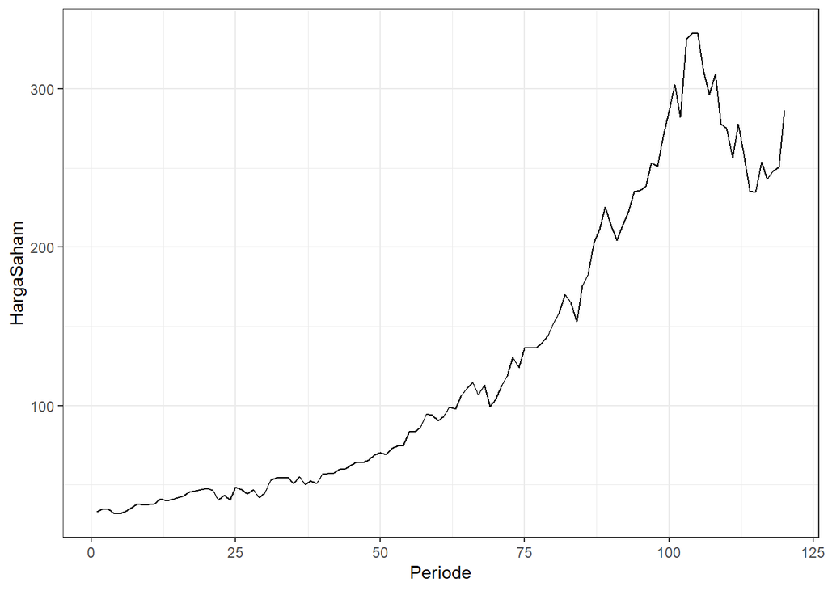

```r
plot_ts <- Data.ts |> as_tsibble() |>
  ggplot(aes(x = Periode, y = HargaSaham)) + geom_line() + theme_bw() +
  xlab("Periode") + ylab("HargaSaham")
plot_ts
```

Berdasarkan plot deret waktu yang ditampilkan, dapat dilihat bahwa data tidak stasioner dalam rataan maupun ragam (pola data tren).

# Plot ACF

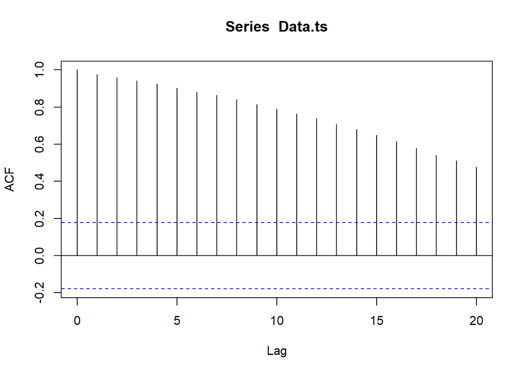

```r
acf(Data.ts)
```

Berdasarkan plot ACF, terlihat bahwa data cenderung tails off yang bermakna bahwa pola data tersebut tidak stasioner.

# Uji ADF

**Pengujian Hipotesis:** $H_0$ : Data tidak stasioner dalam rataan $H_1$ : Data stasioner dalam rataan

```r
tseries::adf.test(Data.ts)
```

```
##
##  Augmented Dickey-Fuller Test
##
## data:  Data.ts
## Dickey-Fuller = -2.2603, Lag order = 4, p-value = 0.4685
## alternative hypothesis: stationary
```

**Interpretasi:** Diperoleh *p-value* sebesar 0.4685 > 0.05, maka Tak Tolak $H_0$. Artinya, belum cukup bukti untuk menyatakan bahwa data stasioner dalam rataan. Dapat dibuktikan juga bahwa pernyataan hasil tersebut sama dan sesuai dengan grafik yang ditunjukkan oleh plot time series dan plot ACF.

# Plot Box-Cox

```r
# Determine the n (Jumlah Data HargaSaham [Price])
n <- length(Data.ts)
n
```

```
## [1] 120
```

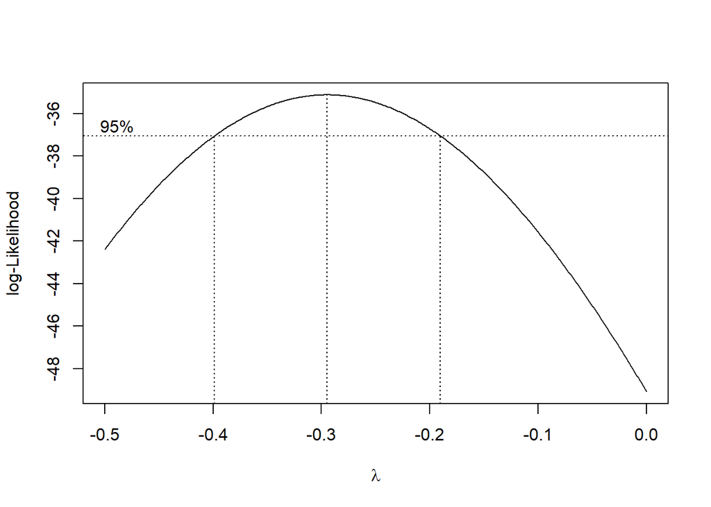

```r
# Plot Visualization
index <- seq(1:n)

boxc <- boxcox(Data.ts~index, lambda = seq(-0.5, 0, by = 0.001))
```

```r
# Rounded Value (Lambda)
lambda <- boxc$x[which.max(boxc$y)]
lambda
```

```
## [1] -0.295
```

```r
# Confidence Interval (CI)
boxc$x[boxc$y > max(boxc$y) - 1/2 * qchisq(0.95, 1)]
```

```
##   [1] -0.398 -0.397 -0.396 -0.395 -0.394 -0.393 -0.392 -0.391 -0.390 -0.389
##  [11] -0.388 -0.387 -0.386 -0.385 -0.384 -0.383 -0.382 -0.381 -0.380 -0.379
##  [21] -0.378 -0.377 -0.376 -0.375 -0.374 -0.373 -0.372 -0.371 -0.370 -0.369
##  [31] -0.368 -0.367 -0.366 -0.365 -0.364 -0.363 -0.362 -0.361 -0.360 -0.359
##  [41] -0.358 -0.357 -0.356 -0.355 -0.354 -0.353 -0.352 -0.351 -0.350 -0.349
##  [51] -0.348 -0.347 -0.346 -0.345 -0.344 -0.343 -0.342 -0.341 -0.340 -0.339
##  [61] -0.338 -0.337 -0.336 -0.335 -0.334 -0.333 -0.332 -0.331 -0.330 -0.329
##  [71] -0.328 -0.327 -0.326 -0.325 -0.324 -0.323 -0.322 -0.321 -0.320 -0.319
##  [81] -0.318 -0.317 -0.316 -0.315 -0.314 -0.313 -0.312 -0.311 -0.310 -0.309
##  [91] -0.308 -0.307 -0.306 -0.305 -0.304 -0.303 -0.302 -0.301 -0.300 -0.299
## [101] -0.298 -0.297 -0.296 -0.295 -0.294 -0.293 -0.292 -0.291 -0.290 -0.289
## [111] -0.288 -0.287 -0.286 -0.285 -0.284 -0.283 -0.282 -0.281 -0.280 -0.279
## [121] -0.278 -0.277 -0.276 -0.275 -0.274 -0.273 -0.272 -0.271 -0.270 -0.269
## [131] -0.268 -0.267 -0.266 -0.265 -0.264 -0.263 -0.262 -0.261 -0.260 -0.259
## [141] -0.258 -0.257 -0.256 -0.255 -0.254 -0.253 -0.252 -0.251 -0.250 -0.249
## [151] -0.248 -0.247 -0.246 -0.245 -0.244 -0.243 -0.242 -0.241 -0.240 -0.239
## [161] -0.238 -0.237 -0.236 -0.235 -0.234 -0.233 -0.232 -0.231 -0.230 -0.229
## [171] -0.228 -0.227 -0.226 -0.225 -0.224 -0.223 -0.222 -0.221 -0.220 -0.219
## [181] -0.218 -0.217 -0.216 -0.215 -0.214 -0.213 -0.212 -0.211 -0.210 -0.209
## [191] -0.208 -0.207 -0.206 -0.205 -0.204 -0.203 -0.202 -0.201 -0.200 -0.199
## [201] -0.198 -0.197 -0.196 -0.195 -0.194 -0.193 -0.192 -0.191
```

**Interpretasi:** Berdasarkan plot box-cox, rounded value ($\lambda$) optimum sebesar -0.295, dan pada selang kepercayaan 95% nilai memiliki batas bawah -0.398 dan batas atas -0.191. Selang tersebut tidak memuat atau mencapai nilai satu, sehingga dapat dikatakan bahwa data harga saham tidak stasioner dalam ragam.

# Part 1

```r
Data.st1 <- Data.ts[1:40] |> ts()
Data.st1
```

```
## Time Series:
## Start = 1
## End = 40
## Frequency = 1
##  [1] 32.93 34.92 34.75 32.06 31.75 33.35 35.67 38.09 37.35 37.74 37.92 41.15
## [13] 40.24 40.95 41.86 43.21 45.43 46.27 46.89 47.88 46.66 40.59 43.67 40.60
## [25] 48.58 47.06 44.46 46.98 42.17 44.75 52.85 54.41 54.32 54.88 50.97 55.05
## [37] 50.00 52.44 51.13 56.60
```

```r
mean(Data.st1)
```

```
## [1] 43.9645
```

```r
var(Data.st1)
```

```
## [1] 50.29265
```

# Time Series Plot

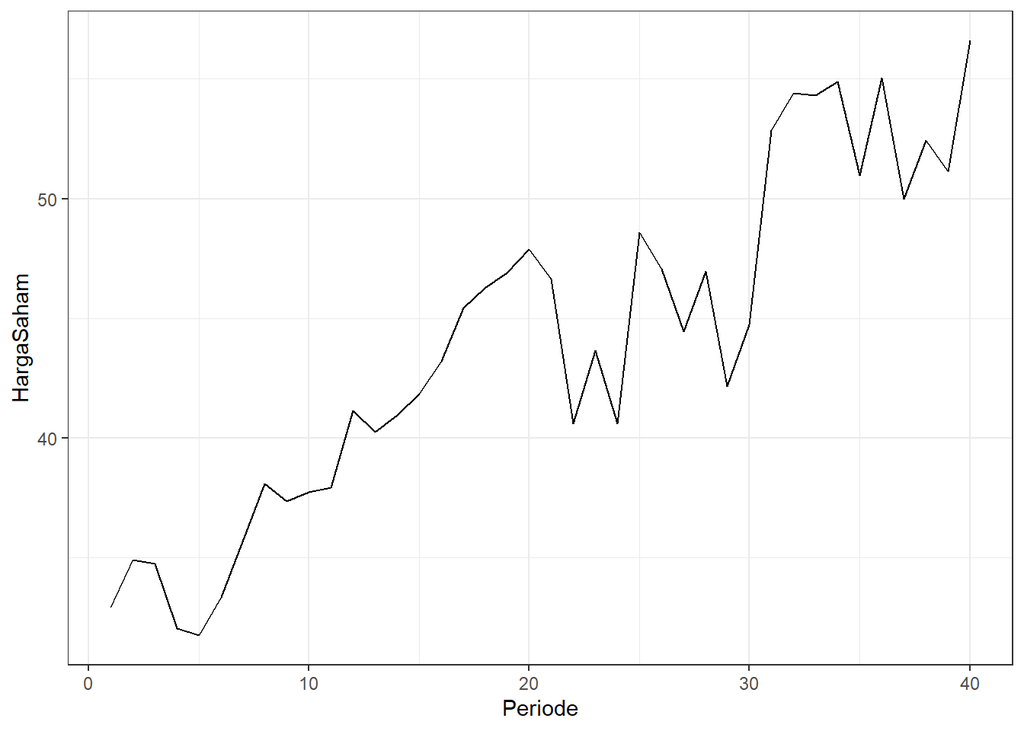

```r
Data.st1 |> as_tsibble() |>
  ggplot(aes(x = index, y = value)) +
  geom_line() + theme_bw() +
  xlab("Periode") + ylab("HargaSaham")
```

**Interpretasi:** Berdasarkan plot deret waktu yang disajikan, dapat dilihat bahwa data tidak stasioner dalam rataan, ditandai dengan data yang tidak menyebar di sekitar nilai tengah. Namun, masih belum dapat dipastikan data tidak stasioner dalam ragam.

# Plot ACF

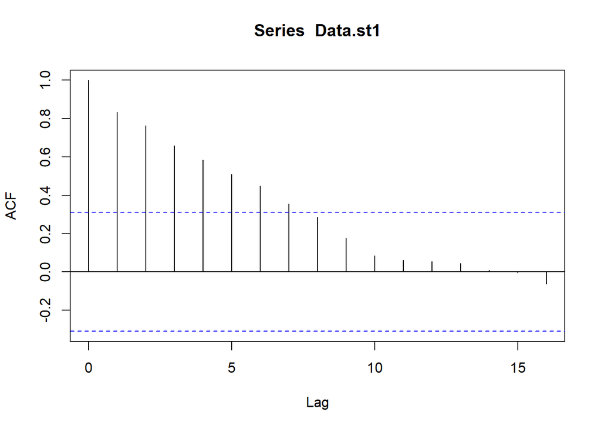

```r
acf(Data.st1)
```

**Interpretasi:** Berdasarkan plot ACF, terlihat bahwa data hasil partisi pertama cenderung *tails off* yang bermakna bahwa data tidak stasioner dalam rataan.

# Uji ADF

**Pengujian Hipotesis:** $H_0$ : Data tidak stasioner dalam rataan $H_1$ : Data stasioner dalam rataan

```r
tseries::adf.test(Data.st1)
```

```
##
##  Augmented Dickey-Fuller Test
##
## data:  Data.st1
## Dickey-Fuller = -3.3047, Lag order = 3, p-value = 0.08544
## alternative hypothesis: stationary
```

**Interpretasi:** Diperoleh *p-value* sebesar 0.08544 > 0.05, maka Tak Tolak $H_0$. Artinya, belum cukup bukti untuk menyatakan bahwa data stasioner dalam rataan. Dapat dibuktikan bahwa pernyataan tersebut sama dan sesuai dengan grafik yang ditunjukkan oleh plot time series dan plot ACF.

# Plot Box-Cox

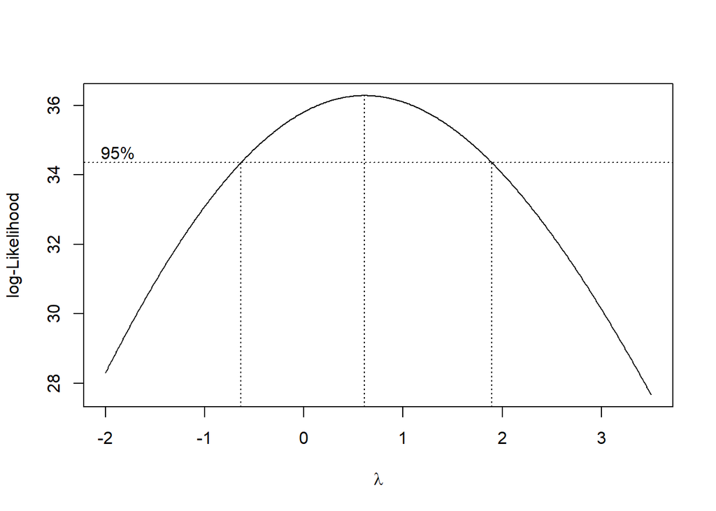

```r
index <- seq(1:40)
boxc <- boxcox(Data.st1~index, lambda = seq(-2, 3.5, by = 0.01))
```

```r
boxc
```

[output not shown]

[output cut: 103 more lines]

```r
# Rounded Value (Lambda)
lambda <- boxc$x[which.max(boxc$y)]
lambda
```

```
## [1] 0.61
```

```r
# Confidence Interval (CI)
boxc$x[boxc$y > max(boxc$y) - 1/2 * qchisq(0.95, 1)]
```

```
##   [1] -0.63 -0.62 -0.61 -0.60 -0.59 -0.58 -0.57 -0.56 -0.55 -0.54 -0.53 -0.52
##  [13] -0.51 -0.50 -0.49 -0.48 -0.47 -0.46 -0.45 -0.44 -0.43 -0.42 -0.41 -0.40
##  [25] -0.39 -0.38 -0.37 -0.36 -0.35 -0.34 -0.33 -0.32 -0.31 -0.30 -0.29 -0.28
##  [37] -0.27 -0.26 -0.25 -0.24 -0.23 -0.22 -0.21 -0.20 -0.19 -0.18 -0.17 -0.16
##  [49] -0.15 -0.14 -0.13 -0.12 -0.11 -0.10 -0.09 -0.08 -0.07 -0.06 -0.05 -0.04
##  [61] -0.03 -0.02 -0.01  0.00  0.01  0.02  0.03  0.04  0.05  0.06  0.07  0.08
##  [73]  0.09  0.10  0.11  0.12  0.13  0.14  0.15  0.16  0.17  0.18  0.19  0.20
##  [85]  0.21  0.22  0.23  0.24  0.25  0.26  0.27  0.28  0.29  0.30  0.31  0.32
##  [97]  0.33  0.34  0.35  0.36  0.37  0.38  0.39  0.40  0.41  0.42  0.43  0.44
## [109]  0.45  0.46  0.47  0.48  0.49  0.50  0.51  0.52  0.53  0.54  0.55  0.56
## [121]  0.57  0.58  0.59  0.60  0.61  0.62  0.63  0.64  0.65  0.66  0.67  0.68
## [133]  0.69  0.70  0.71  0.72  0.73  0.74  0.75  0.76  0.77  0.78  0.79  0.80
## [145]  0.81  0.82  0.83  0.84  0.85  0.86  0.87  0.88  0.89  0.90  0.91  0.92
## [157]  0.93  0.94  0.95  0.96  0.97  0.98  0.99  1.00  1.01  1.02  1.03  1.04
## [169]  1.05  1.06  1.07  1.08  1.09  1.10  1.11  1.12  1.13  1.14  1.15  1.16
## [181]  1.17  1.18  1.19  1.20  1.21  1.22  1.23  1.24  1.25  1.26  1.27  1.28
## [193]  1.29  1.30  1.31  1.32  1.33  1.34  1.35  1.36  1.37  1.38  1.39  1.40
## [205]  1.41  1.42  1.43  1.44  1.45  1.46  1.47  1.48  1.49  1.50  1.51  1.52
## [217]  1.53  1.54  1.55  1.56  1.57  1.58  1.59  1.60  1.61  1.62  1.63  1.64
## [229]  1.65  1.66  1.67  1.68  1.69  1.70  1.71  1.72  1.73  1.74  1.75  1.76
## [241]  1.77  1.78  1.79  1.80  1.81  1.82  1.83  1.84  1.85  1.86  1.87  1.88
## [253]  1.89
```

**Interpretasi:** Berdasarkan plot box-cox, diperoleh rounded value ($\lambda$) optimum sebesar 0.61 dan pada selang kepercayaan 95% nilai memiliki batas bawah -0.63 dan batas atas 1.89. Selang tersebut memuat dan mencapai nilai satu, sehingga dapat dikatakan bahwa data harga saham (price) stasioner dalam ragam.

# Part 2

```r
Data.st2 <- Data.ts[1:80] |> ts()
Data.st2
```

```
## Time Series:
## Start = 1
## End = 80
## Frequency = 1
##  [1]  32.93  34.92  34.75  32.06  31.75  33.35  35.67  38.09  37.35  37.74
## [11]  37.92  41.15  40.24  40.95  41.86  43.21  45.43  46.27  46.89  47.88
## [21]  46.66  40.59  43.67  40.60  48.58  47.06  44.46  46.98  42.17  44.75
## [31]  52.85  54.41  54.32  54.88  50.97  55.05  50.00  52.44  51.13  56.60
## [41]  57.01  57.41  59.97  60.11  62.79  64.36  64.13  65.81  68.68  70.24
## [51]  69.33  73.10  74.71  74.71  83.68  83.60  86.13  94.79  93.99  90.47
## [61]  93.21  99.28  98.10 106.03 110.85 114.75 107.05 113.00  99.55 103.78
## [71] 112.89 118.95 130.53 123.85 136.63 137.00 136.61 139.66 144.26 151.81
```

```r
mean(Data.st2)
```

```
## [1] 69.89238
```

```r
var(Data.st2)
```

```
## [1] 1084.168
```

# Time Series Plot

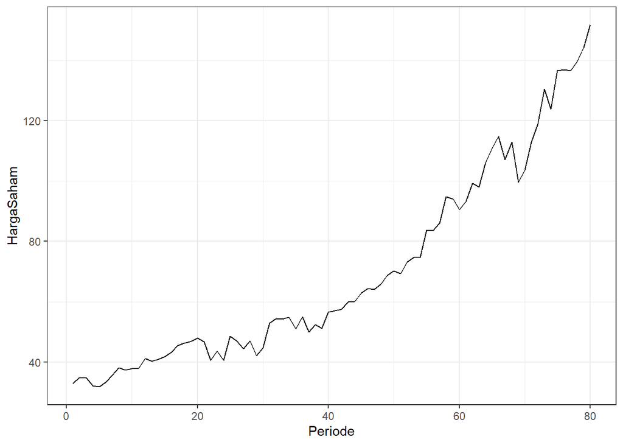

```r
Data.st2 |> as_tsibble() |>
  ggplot(aes(x = index, y = value)) +
  geom_line() + theme_bw() +
  xlab("Periode") + ylab("HargaSaham")
```

**Interpretasi:** Berdasarkan plot deret waktu yang disajikan, dapat dilihat bahwa data tidak stasioner dalam rataan dan ragam, ditunjukkan dengan bentuk/pola data yang tidak menyebar di sekitar nilai tengah, serta lebar pita yang cenderung berbeda.

# Plot ACF

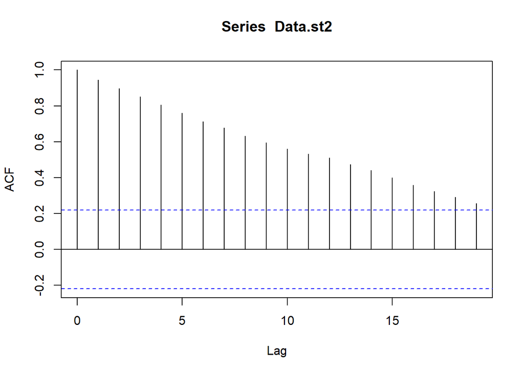

```r
acf(Data.st2)
```

**Interpretasi:** Berdasarkan plot ACF, dapat dilihat bahwa data hasil partisi kedua cenderung *tails off* yang bermakna bahwa data tidak stasioner dalam rataan.

# Uji ADF

**Pengujian Hipotesis:** $H_0$ : Data tidak stasioner dalam rataan $H_1$ : Data stasioner dalam rataan

```r
adf.test(Data.st2)
```

```
##
##  Augmented Dickey-Fuller Test
##
## data:  Data.st2
## Dickey-Fuller = 0.50773, Lag order = 4, p-value = 0.99
## alternative hypothesis: stationary
```

**Interpretasi:** Diperoleh *p-value* sebesar 0.99 > 0.05, maka Tak Tolak $H_0$. Artinya, belum cukup bukti untuk menyatakan bahwa data stasioner dalam rataan. Dapat dibuktikan bahwa pernyataan tersebut sama atau sesuai dengan grafik yang ditunjukkan oleh plot time series dan plot ACF.

# Plot Box-Cox

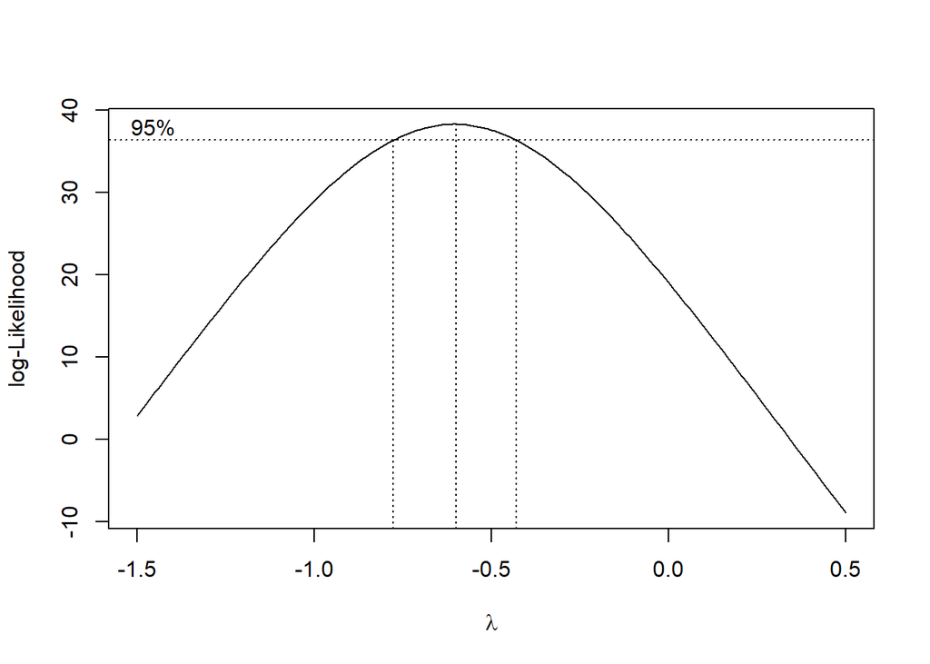

```r
index <- seq(1:80)
boxc = boxcox(Data.st2~index, lambda = seq(-1.5, 0.5, by = 0.01))
```

```r
boxc
```

[output not shown]

[output cut: 39 more lines]

```r
# Rounded Value (Lambda)
lambda <- boxc$x[which.max(boxc$y)]
lambda
```

```
## [1] -0.6
```

```r
# Confidence Interval (CI)s
boxc$x[boxc$y > max(boxc$y) - 1/2 * qchisq(0.95, 1)]
```

```
##  [1] -0.77 -0.76 -0.75 -0.74 -0.73 -0.72 -0.71 -0.70 -0.69 -0.68 -0.67 -0.66
## [13] -0.65 -0.64 -0.63 -0.62 -0.61 -0.60 -0.59 -0.58 -0.57 -0.56 -0.55 -0.54
## [25] -0.53 -0.52 -0.51 -0.50 -0.49 -0.48 -0.47 -0.46 -0.45 -0.44
```

**Interpretasi:** Berdasarkan plot box-cox, diperoleh rounded value ($\lambda$) optimum sebesar -0.6 dan pada selang kepercayaan 95% nilai memiliki batas bawah -0.77 dan batas atas -0.44. Selang tersebut tidak memuat dan mencapai nilai satu, sehingga dapat dikatakan bahwa data harga saham (price) tidak stasioner dalam ragam.